# Personalized Design Recommendation Report

MLE-Based Analysis for Spatial CRT Treatment Assignment

Author

Andrew Walther

Published

September 24, 2026

# 1 Executive Summary

This report is a narrative companion to the `MLE_tau_sweep_design_recommendations_queen.pdf` figure file (and its rook counterpart `..._rook.pdf`), produced by `run_recommendation_report()` separately for each neighbor type. It provides narrative explanations of **how each analysis was computed**, **what each figure and table shows**, and **what the results show** for researchers designing spatial cluster randomized trials (CRTs). The statements below describe the simulation results; they are not the study’s final design recommendation, which has not yet been chosen.

The results are those of the 2026-09 revised simulation (matched incidence surfaces, oracle estimator). The simulation evaluates **8 treatment assignment designs** across **1280 parameter scenarios under queen contiguity** (the primary neighbor structure; rook contiguity is a sensitivity analysis summarized in Section 10), using maximum likelihood estimation of a spatial autoregressive lag model (the oracle model $Y \sim Z + \text{Spill} + X$, fit with the lean ML engine `fit_sar_lag()`, which matches `spatialreg::lagsarlm` to about $10^{-7}$). The estimand is the direct treatment effect $\tau$ (primary scenario: $\tau = 1.0$; sensitivity across $\tau \in \{0.8, 1.5, 2.0, 3.0\}$ in Section 11).

Three analytical questions are addressed:

Lowest-average-MSE design for each of the 5 incidence configurations (queen contiguity, tau = 1.0).

| Incidence Config | Best Design | Avg MSE | Avg Coverage |
| --- | --- | --- | --- |
| iid Uniform | D3: Sat. Quadrants | 0.0913 | 0.934 |
| Poisson (rho_X = 0.20) | D3: Sat. Quadrants | 0.0866 | 0.939 |
| Poisson (rho_X = 0.50) | D3: Sat. Quadrants | 0.0899 | 0.937 |
| Spatial (rho_X = 0.20) | D8: Inc.-Guided Sat. Q. | 0.0871 | 0.942 |
| Spatial (rho_X = 0.50) | D8: Inc.-Guided Sat. Q. | 0.0916 | 0.934 |

**Key finding (queen):** Saturation Quadrants has the lowest average MSE in 3 of 5 incidence configurations and Incidence-Guided Saturation Quadrants in the others; the two saturation-quadrant designs are statistically indistinguishable (see Section 9.2). Checkerboard has the highest average MSE in every configuration. Coverage is near-nominal (0.931–0.943) for every design under queen, so it does not separate the designs; MSE does. Spillover type (control-only vs. both) is by far the most influential parameter for every design except Isolation Buffer, while spatial autocorrelation $\rho$ and spillover magnitude $\gamma$ have secondary effects.

# 2 Study Background

## 2.1 Designs Evaluated

8 treatment assignment strategies are compared. Every design except Isolation Buffer treats exactly 50 of the 100 clusters ($10 \times 10$ grid); Isolation Buffer treats a maximal independent set (about 22 clusters under queen, 38 under rook). Designs that use incidence rank the clusters’ incidence $X_k$ with ties broken at random for every draw:

8 treatment assignment designs evaluated. Deterministic designs (1) produce one assignment used for every fit; stochastic designs draw 25 assignments on each of the 10 incidence surfaces.

| ID | Name | Deterministic? | Description |
| --- | --- | --- | --- |
| 1 | Checkerboard | Yes | Alternating grid pattern; maximizes spatial separation of treated and control units |
| 2 | High Incidence Focus | No | Treats the 50 highest-incidence clusters (random tie-breaking) |
| 3 | Saturation Quadrants | No | Assigns random saturation levels (0.2--0.8) within each of four spatial quadrants |
| 4 | Isolation Buffer | No | Greedy assignment ensuring no two adjacent clusters are both treated |
| 5 | 2x2 Blocking | No | 1:1 randomization within non-overlapping 2x2 spatial blocks |
| 6 | Balanced Quartiles | No | Stratified randomization balanced within incidence quartiles |
| 7 | Balanced Halves | No | Stratified randomization balanced within incidence halves (above/below median) |
| 8 | Incidence-Guided Saturation Quadrants | No | Quadrant saturations 0.8/0.6/0.4/0.2 assigned by rank of quadrant mean incidence |

## 2.2 Performance Metrics

For each of the 1280 scenarios, **250 model fits** (10 incidence surfaces $X_k$ $\times$ 25 design draws per surface; each draw is made from $X_k$, the outcome and analysis use the same $X_k$, and every fit has its own noise column) produce the following metrics:

- **Bias** $= \bar{\hat{\tau}} - \tau$: average departure from true effect (primary $\tau = 1.0$)
- **SD**: standard deviation of estimates across iterations
- **MSE** $= \text{Bias}^2 + \text{SD}^2$: total estimation error; the **primary ranking criterion** throughout this report
- **Coverage**: fraction of 95% confidence intervals containing the true $\tau$

Lower MSE is better. Coverage near 0.95 (the nominal level) indicates valid inference.

## 2.3 Simulation Parameter Space

Simulation parameter grid. Each of the 1280 queen-contiguity scenarios (tau = 1.0) is a unique combination of (incidence config, Rho, Gamma, Spillover type, Design). Results are always reported separately by incidence config and never pooled over rook and queen.

| Parameter | Values | Levels |
| --- | --- | --- |
| Incidence mode | iid, spatial, poisson | 5 configs |
| rho\_X (incidence spatial autocorr.) | N/A (iid); 0.2, 0.5 (Spatial, Poisson) | --- |
| nb\_type (contiguity) | queen (primary; rook is a sensitivity analysis) | 1 |
| Rho (outcome spatial autocorr.) | 0, 0.01, 0.2, 0.5 | 4 |
| Gamma (spillover magnitude) | 0.5, 0.6, 0.7, 0.8 | 4 |
| Spillover type | both, control_only | 2 |
| Design | 1, 2, 3, 4, 5, 6, 7, 8 | 8 |
| TOTAL |  | 1280 scenarios |

# 3 Analytical Methods

This section explains exactly how each analysis in the recommendation report is computed.

## 3.1 Core Ranking Method: `rank_designs_by_group()`

All conditional rankings in this report share the same logic, implemented in `rank_designs_by_group()`:

1. **Group** the 256 scenarios within an incidence config by the requested conditioning variables plus Design (e.g., group by `{Rho, Design}`)
2. **Aggregate**: compute average MSE, Coverage, Bias, and SD within each group
3. **Rank**: within each unique combination of the conditioning variables, assign integer ranks to designs based on ascending average MSE (rank 1 = best; ties broken using minimum rank)
4. **Return** a tidy data frame with one row per `{group, Design}` combination

This is the same ranking logic used in `table_design_ranks()` in `06_visualizations.R`, extended to support arbitrary conditioning sets.

**Critical invariant:** Rankings are **always computed within a single incidence configuration**. Results are never aggregated across the 5 incidence configs because each represents a fundamentally different assumption about how prior incidence data arises.

## 3.2 Q1 — Per-Config Rankings: `table_incidence_rankings()` and `plot_incidence_rankings()`

**What is computed:** For each of the 5 incidence configs, all 256 scenarios (8 designs $\times$ 32 parameter combinations) are summarized by computing the average MSE per design. Designs are then ranked 1–8 (lowest = best) within each config.

**What the figure shows** (Page 1 of PDF): A faceted bar chart with one panel per incidence config. Bars represent average MSE per design, sorted from lowest to highest within each panel. Rank labels (1–8) appear above each bar.

**How to read it:** Lower bars are better. Rank labels allow quick comparison across panels. A design ranked consistently high across all panels performs well regardless of how incidence was generated.

## 3.3 Q2 — Marginal Rankings: `table_marginal_rankings()` and `plot_rank_trajectories()`

**What “marginal” means:** For a parameter like Rho, we want to know: ignoring all other parameters, how does each design rank when Rho takes a specific value? This is computed by grouping all scenarios by `{Rho, Design}` and averaging MSE across the remaining parameters (Gamma, Spillover_Type); Neighbor_Type is fixed at queen.

**What the rank trajectory plot shows**: A line plot where the x-axis is the parameter level, the y-axis is design rank (1 at top, 8 at bottom), and each line traces one design. Crossing lines indicate a **rank reversal**: a design that is best at one parameter level but not at another.

**What the marginal ranking table shows**: A wide table with parameter levels as column headers and designs as rows. Each cell reports `Avg_MSE (#Rank)` at that parameter level, averaged over all other parameters. Designs are ordered by their overall rank (best at top).

**What the conditional MSE boxplot shows**: Rather than averages, this shows the **full distribution** of raw scenario-level MSE values for each design at each parameter level. This reveals whether a design’s advantage is consistent or comes from a few favorable extreme scenarios.

## 3.4 Q3 — Best Design Heatmap: `plot_best_design_heatmap()`

**What is computed:** For every combination of two parameters (e.g., Rho and Gamma), all scenarios sharing that combination are grouped, average MSE is computed per design, and the design with the minimum average MSE is identified as the winner.

**What the heatmap shows**: A grid of colored tiles where each cell corresponds to one `{Rho, Gamma}` combination. The color and text label identify the winning design. The MSE value inside each tile is the winning design’s average MSE at that combination.

**Interpretation guidance:** If one design wins all tiles, it dominates unconditionally. If tiles show different winners, the choice of design should adapt to the anticipated parameter regime.

## 3.5 Programmatic Commentary: `generate_commentary()`

For each incidence config, six structured findings are automatically derived from the results:

| Finding | Computed as |
| --- | --- |
| Overall winner | Design with Rank 1 from ungrouped `rank_designs_by_group()` |
| Dominance % | From scenario-level pairwise comparison: $\frac{\#\{s : \text{MSE}_{\text{best},s} < \text{MSE}_{\text{2nd},s}\}}{32}$ |
| Rank stability | Whether the best design holds rank 1 at every level of Rho and every level of Gamma |
| Coverage | Average Coverage for the best and worst designs |
| Sensitivity | Eta-squared ($\eta^2 = SS_{\text{between}} / SS_{\text{total}}$) for each parameter |
| Summary | Template string synthesizing findings 1–5 (descriptive) |

# 4 Q1: Design Rankings by Incidence Mode

## 4.1 Cross-Config MSE Rankings

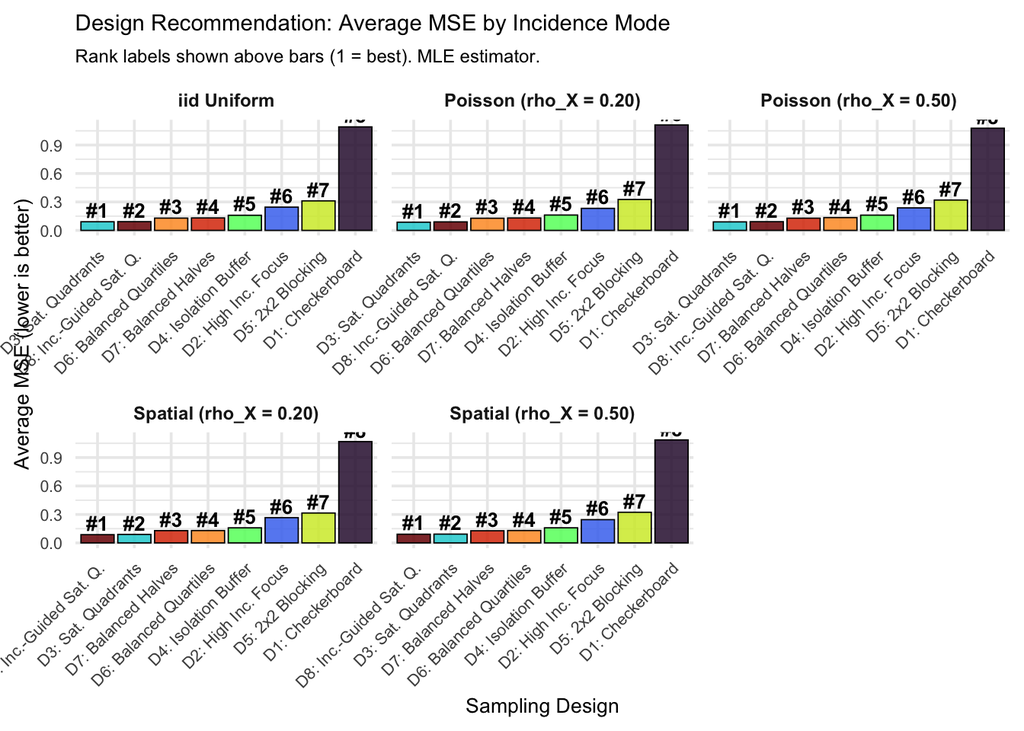

Average MSE per design for each of the 5 incidence configurations (queen contiguity, tau = 1.0). Bars are sorted left-to-right within each panel by MSE (lowest = best). Rank labels above bars. Lower bars are better. Note the shared y-axis: Checkerboard’s much higher MSE compresses the other bars.

**Reading the plot:** The 5 panels correspond to the 5 incidence configurations. Within each panel, designs are arranged from best (left) to worst (right), with the rank number printed above each bar. The two saturation-quadrant designs (Saturation Quadrants and Incidence-Guided Saturation Quadrants) occupy the two leftmost positions in every panel.

**Key observation:** Saturation Quadrants ranks first in 3 of 5 incidence configurations; the winning design’s average MSE ranges from 0.087 to 0.092 depending on the config. The worst design (Checkerboard) has 11.8–12.8x the winner’s MSE in every configuration.

## 4.2 Cross-Config Coverage Rankings

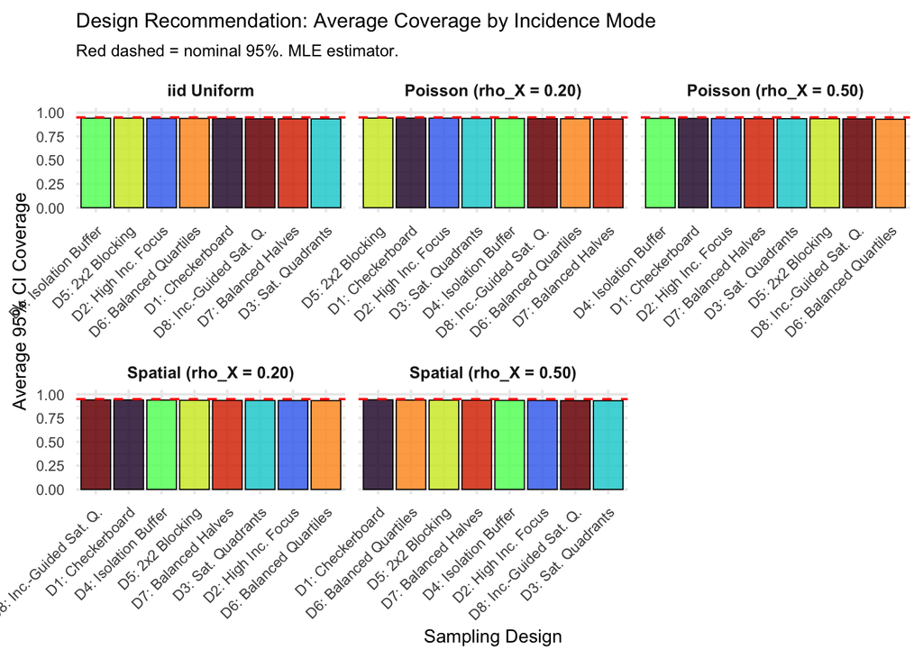

Average 95% CI coverage probability per design for each incidence configuration (queen contiguity, tau = 1.0). Red dashed line = nominal 0.95. Under queen, every design’s average coverage lies in 0.931–0.943, so coverage does not separate the designs.

**Reading the plot:** The red dashed line at 0.95 is the nominal coverage target. Bars above this line are over-covering (conservative CIs); bars below are under-covering (anti-conservative). Under queen, every design, including Checkerboard (0.939–0.943), is close to nominal (0.931–0.943); the roughly one-point shortfall is the finite-sample behavior of the Wald interval.

**Key observation:** Coverage does not separate the designs under queen; MSE does. The one coverage failure in the study is Checkerboard under rook contiguity, where $WZ = 1 - Z$, $\tau$ is not identified, and coverage falls to 0.15 (see Section 10).

## 4.3 Detailed Rankings by Incidence Config

MLE design rankings for iid Uniform (queen). Runner-up MSE is 1.3% higher than the winner; worst design MSE is 12.0x higher.

| Rank | Design | Avg MSE | Avg Coverage | Avg Bias |
| --- | --- | --- | --- | --- |
| 1 | D3: Sat. Quadrants | 0.0913 | 0.934 | 0.0221 |
| 2 | D8: Inc.-Guided Sat. Q. | 0.0925 | 0.935 | 0.0317 |
| 3 | D6: Balanced Quartiles | 0.1296 | 0.939 | 0.0134 |
| 4 | D7: Balanced Halves | 0.1316 | 0.935 | 0.0168 |
| 5 | D4: Isolation Buffer | 0.1596 | 0.941 | 0.0120 |
| 6 | D2: High Inc. Focus | 0.2455 | 0.939 | 0.0347 |
| 7 | D5: 2x2 Blocking | 0.3115 | 0.941 | 0.0079 |
| 8 | D1: Checkerboard | 1.0915 | 0.939 | -0.0004 |

MLE design rankings for Poisson (rho X = 0.20) (queen). Runner-up MSE is 3.9% higher than the winner; worst design MSE is 12.8x higher.

| Rank | Design | Avg MSE | Avg Coverage | Avg Bias |
| --- | --- | --- | --- | --- |
| 1 | D3: Sat. Quadrants | 0.0866 | 0.939 | 0.0230 |
| 2 | D8: Inc.-Guided Sat. Q. | 0.0900 | 0.937 | 0.0333 |
| 3 | D6: Balanced Quartiles | 0.1285 | 0.936 | 0.0175 |
| 4 | D7: Balanced Halves | 0.1312 | 0.933 | 0.0162 |
| 5 | D4: Isolation Buffer | 0.1620 | 0.938 | -0.0016 |
| 6 | D2: High Inc. Focus | 0.2324 | 0.941 | 0.0334 |
| 7 | D5: 2x2 Blocking | 0.3264 | 0.942 | 0.0134 |
| 8 | D1: Checkerboard | 1.1116 | 0.942 | 0.0076 |

MLE design rankings for Poisson (rho X = 0.50) (queen). Runner-up MSE is 2.4% higher than the winner; worst design MSE is 12.0x higher.

| Rank | Design | Avg MSE | Avg Coverage | Avg Bias |
| --- | --- | --- | --- | --- |
| 1 | D3: Sat. Quadrants | 0.0899 | 0.937 | 0.0250 |
| 2 | D8: Inc.-Guided Sat. Q. | 0.0921 | 0.935 | 0.0328 |
| 3 | D7: Balanced Halves | 0.1290 | 0.937 | 0.0137 |
| 4 | D6: Balanced Quartiles | 0.1351 | 0.931 | 0.0168 |
| 5 | D4: Isolation Buffer | 0.1609 | 0.940 | 0.0009 |
| 6 | D2: High Inc. Focus | 0.2376 | 0.938 | 0.0358 |
| 7 | D5: 2x2 Blocking | 0.3200 | 0.937 | 0.0084 |
| 8 | D1: Checkerboard | 1.0773 | 0.939 | 0.0011 |

MLE design rankings for Spatial (rho X = 0.20) (queen). Runner-up MSE is 3.1% higher than the winner; worst design MSE is 12.3x higher.

| Rank | Design | Avg MSE | Avg Coverage | Avg Bias |
| --- | --- | --- | --- | --- |
| 1 | D8: Inc.-Guided Sat. Q. | 0.0871 | 0.942 | 0.0278 |
| 2 | D3: Sat. Quadrants | 0.0898 | 0.936 | 0.0252 |
| 3 | D7: Balanced Halves | 0.1296 | 0.936 | 0.0224 |
| 4 | D6: Balanced Quartiles | 0.1303 | 0.934 | 0.0176 |
| 5 | D4: Isolation Buffer | 0.1591 | 0.940 | 0.0048 |
| 6 | D2: High Inc. Focus | 0.2665 | 0.935 | 0.0251 |
| 7 | D5: 2x2 Blocking | 0.3152 | 0.937 | 0.0169 |
| 8 | D1: Checkerboard | 1.0682 | 0.942 | 0.0070 |

MLE design rankings for Spatial (rho X = 0.50) (queen). Runner-up MSE is 1.2% higher than the winner; worst design MSE is 11.9x higher.

| Rank | Design | Avg MSE | Avg Coverage | Avg Bias |
| --- | --- | --- | --- | --- |
| 1 | D8: Inc.-Guided Sat. Q. | 0.0916 | 0.934 | 0.0350 |
| 2 | D3: Sat. Quadrants | 0.0927 | 0.934 | 0.0277 |
| 3 | D7: Balanced Halves | 0.1283 | 0.937 | 0.0186 |
| 4 | D6: Balanced Quartiles | 0.1306 | 0.940 | 0.0211 |
| 5 | D4: Isolation Buffer | 0.1593 | 0.936 | -0.0030 |
| 6 | D2: High Inc. Focus | 0.2453 | 0.936 | 0.0273 |
| 7 | D5: 2x2 Blocking | 0.3231 | 0.939 | 0.0012 |
| 8 | D1: Checkerboard | 1.0858 | 0.943 | -0.0096 |

**Notable patterns across configs (queen):**

- **Saturation Quadrants** ranks 1st in 3 of 5 configs. Its runner-up margin ranges from 1.1% to 4% depending on incidence configuration.
- **Incidence-Guided Saturation Quadrants** is the most consistent runner-up, ranking 2nd in 3 of 5 configs.
- **Saturation Quadrants** ranks 2nd in the remaining 2 config(s).
- **Checkerboard** is last in all configs with MSE 11.8–12.8x that of the winner, although its coverage is near-nominal (at most 0.94).

# 5 Q2: Marginal Rankings by Parameter Level

This section answers: **holding all other parameters at their average, how does each design’s rank change as one parameter varies?**

## 5.1 Effect of Outcome Spatial Autocorrelation (Rho)

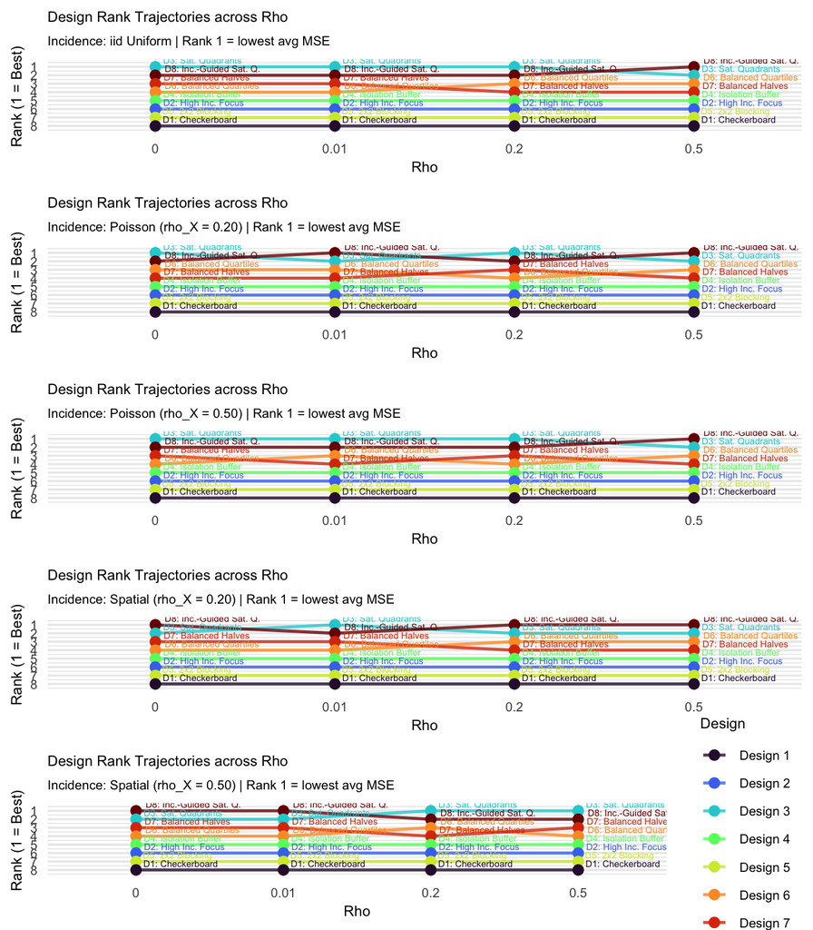

Design rank trajectories across Rho for each incidence config (one panel per config). Rank 1 = best. Lines that stay flat indicate robust designs; crossing lines reveal parameter-driven rank reversals (queen contiguity).

**How to read the trajectory plots:** Rank 1 sits at the top; rank 8 at the bottom. A flat horizontal line means a design’s rank does not change as Rho increases. A downward slope means the design falls in rank as Rho increases. Crossing lines between two designs indicate a rank reversal.

**Findings:**

- **Saturation Quadrants** does not hold rank 1 at every Rho level; it cedes rank 1 in: iid Uniform at Rho=0.5; Poisson (rho_X = 0.20) at Rho=0.01,0.5; Poisson (rho_X = 0.50) at Rho=0.5; Spatial (rho_X = 0.20) at Rho=0,0.2,0.5; Spatial (rho_X = 0.50) at Rho=0,0.01. At every Rho level in every config, ranks 1 and 2 are held by the two saturation-quadrant designs, so the exceptions are swaps within that pair.
- **Checkerboard** consistently occupies last rank across all Rho values, confirming its failure is not a high-Rho artifact.

## 5.2 Effect of Spillover Magnitude (Gamma)

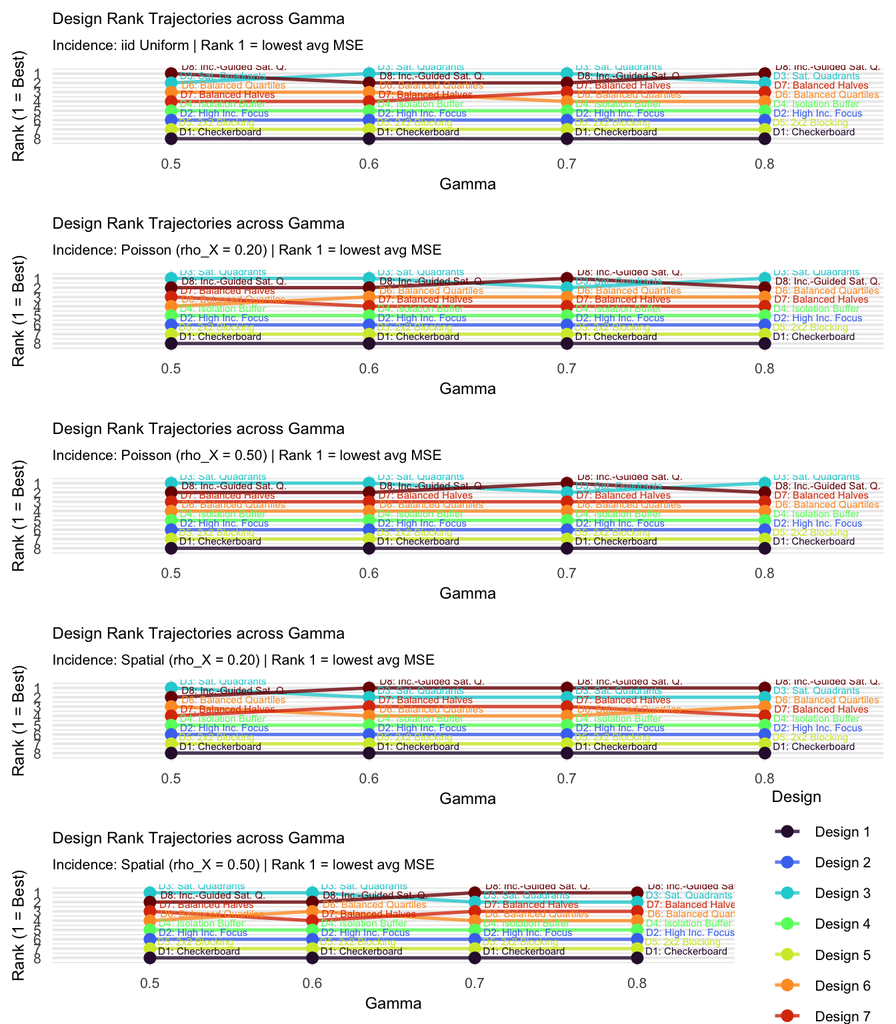

Design rank trajectories across Gamma. Gamma controls the magnitude of treatment spillover to neighbors (queen contiguity). For Saturation Quadrants, Gamma explains little MSE variation (eta-squared at most 0.011 across configs).

**Findings:** Across Gamma = 0.5 to 0.8, the design rankings change only by swaps between designs with near-identical MSE: the two saturation-quadrant designs hold ranks 1 and 2 at every Gamma level in every config (trading places), and ranks 5 to 8 do not change at all. For Saturation Quadrants, Gamma explains at most 2% of MSE variation (eta-squared $\le$ 0.011). Isolation Buffer differs from the other designs: spillover type explains almost none of its MSE variation (eta-squared below 0.05 in every config under queen, versus above 0.9 for every other design; computed from the queen, tau = 1.0 slice with the same $SS_{\text{between}}/SS_{\text{total}}$ formula used in the per-config findings).

## 5.3 Marginal Ranking Tables

The following tables report average MSE (and rank in parentheses) at each level of each key parameter, averaged over all other simulation parameters.

### 5.3.1 iid Uniform

iid Uniform | Marginal rankings by Rho (outcome spatial autocorrelation). Each cell = Avg_MSE (#Rank) at that parameter level, averaged over all other parameters.

| Design | Rho=0 | Rho=0.01 | Rho=0.2 | Rho=0.5 |
| --- | --- | --- | --- | --- |
| D3: Sat. Quadrants | 0.0910 (#1) | 0.0876 (#1) | 0.0901 (#1) | 0.0964 (#2) |
| D8: Inc.-Guided Sat. Q. | 0.0942 (#2) | 0.0903 (#2) | 0.0933 (#2) | 0.0923 (#1) |
| D6: Balanced Quartiles | 0.1240 (#4) | 0.1380 (#4) | 0.1270 (#3) | 0.1296 (#3) |
| D7: Balanced Halves | 0.1234 (#3) | 0.1292 (#3) | 0.1378 (#4) | 0.1359 (#4) |
| D4: Isolation Buffer | 0.1616 (#5) | 0.1545 (#5) | 0.1599 (#5) | 0.1623 (#5) |
| D2: High Inc. Focus | 0.2469 (#6) | 0.2406 (#6) | 0.2510 (#6) | 0.2434 (#6) |
| D5: 2x2 Blocking | 0.3050 (#7) | 0.3042 (#7) | 0.3105 (#7) | 0.3261 (#7) |
| D1: Checkerboard | 1.1350 (#8) | 1.0484 (#8) | 1.1407 (#8) | 1.0419 (#8) |

iid Uniform | Marginal rankings by Gamma (spillover magnitude). Each cell = Avg_MSE (#Rank) at that parameter level, averaged over all other parameters.

| Design | Gamma=0.5 | Gamma=0.6 | Gamma=0.7 | Gamma=0.8 |
| --- | --- | --- | --- | --- |
| D3: Sat. Quadrants | 0.0936 (#2) | 0.0894 (#1) | 0.0906 (#1) | 0.0916 (#2) |
| D8: Inc.-Guided Sat. Q. | 0.0919 (#1) | 0.0956 (#2) | 0.0959 (#2) | 0.0866 (#1) |
| D6: Balanced Quartiles | 0.1300 (#3) | 0.1242 (#3) | 0.1322 (#4) | 0.1321 (#4) |
| D7: Balanced Halves | 0.1371 (#4) | 0.1339 (#4) | 0.1242 (#3) | 0.1311 (#3) |
| D4: Isolation Buffer | 0.1566 (#5) | 0.1627 (#5) | 0.1575 (#5) | 0.1615 (#5) |
| D2: High Inc. Focus | 0.2398 (#6) | 0.2641 (#6) | 0.2405 (#6) | 0.2375 (#6) |
| D5: 2x2 Blocking | 0.3036 (#7) | 0.3209 (#7) | 0.2987 (#7) | 0.3227 (#7) |
| D1: Checkerboard | 1.1030 (#8) | 1.0440 (#8) | 1.0134 (#8) | 1.2055 (#8) |

iid Uniform | Marginal rankings by Spillover Type. Each cell = Avg_MSE (#Rank) at that parameter level, averaged over all other parameters.

| Design | Spillover_Type=both | Spillover_Type=control_only |
| --- | --- | --- |
| D3: Sat. Quadrants | 0.0449 (#3) | 0.1377 (#1) |
| D8: Inc.-Guided Sat. Q. | 0.0456 (#4) | 0.1394 (#2) |
| D6: Balanced Quartiles | 0.0423 (#2) | 0.2170 (#4) |
| D7: Balanced Halves | 0.0418 (#1) | 0.2214 (#5) |
| D4: Isolation Buffer | 0.1624 (#8) | 0.1568 (#3) |
| D2: High Inc. Focus | 0.1614 (#7) | 0.3296 (#6) |
| D5: 2x2 Blocking | 0.0621 (#5) | 0.5608 (#7) |
| D1: Checkerboard | 0.0635 (#6) | 2.1194 (#8) |

### 5.3.2 Poisson (rho_X = 0.20)

Poisson (rho X = 0.20) | Marginal rankings by Rho (outcome spatial autocorrelation). Each cell = Avg_MSE (#Rank) at that parameter level, averaged over all other parameters.

| Design | Rho=0 | Rho=0.01 | Rho=0.2 | Rho=0.5 |
| --- | --- | --- | --- | --- |
| D3: Sat. Quadrants | 0.0854 (#1) | 0.0870 (#2) | 0.0818 (#1) | 0.0921 (#2) |
| D8: Inc.-Guided Sat. Q. | 0.0872 (#2) | 0.0863 (#1) | 0.0959 (#2) | 0.0908 (#1) |
| D6: Balanced Quartiles | 0.1242 (#3) | 0.1221 (#3) | 0.1358 (#4) | 0.1316 (#3) |
| D7: Balanced Halves | 0.1394 (#4) | 0.1274 (#4) | 0.1213 (#3) | 0.1367 (#4) |
| D4: Isolation Buffer | 0.1641 (#5) | 0.1613 (#5) | 0.1591 (#5) | 0.1633 (#5) |
| D2: High Inc. Focus | 0.2308 (#6) | 0.2229 (#6) | 0.2398 (#6) | 0.2361 (#6) |
| D5: 2x2 Blocking | 0.3354 (#7) | 0.3221 (#7) | 0.3162 (#7) | 0.3320 (#7) |
| D1: Checkerboard | 1.1066 (#8) | 1.1141 (#8) | 1.0886 (#8) | 1.1373 (#8) |

Poisson (rho X = 0.20) | Marginal rankings by Gamma (spillover magnitude). Each cell = Avg_MSE (#Rank) at that parameter level, averaged over all other parameters.

| Design | Gamma=0.5 | Gamma=0.6 | Gamma=0.7 | Gamma=0.8 |
| --- | --- | --- | --- | --- |
| D3: Sat. Quadrants | 0.0868 (#1) | 0.0847 (#1) | 0.0900 (#2) | 0.0848 (#1) |
| D8: Inc.-Guided Sat. Q. | 0.0902 (#2) | 0.0935 (#2) | 0.0877 (#1) | 0.0887 (#2) |
| D6: Balanced Quartiles | 0.1319 (#4) | 0.1245 (#3) | 0.1261 (#3) | 0.1314 (#3) |
| D7: Balanced Halves | 0.1271 (#3) | 0.1293 (#4) | 0.1331 (#4) | 0.1353 (#4) |
| D4: Isolation Buffer | 0.1610 (#5) | 0.1632 (#5) | 0.1587 (#5) | 0.1650 (#5) |
| D2: High Inc. Focus | 0.2286 (#6) | 0.2333 (#6) | 0.2456 (#6) | 0.2220 (#6) |
| D5: 2x2 Blocking | 0.3199 (#7) | 0.3205 (#7) | 0.3479 (#7) | 0.3173 (#7) |
| D1: Checkerboard | 1.1750 (#8) | 1.1034 (#8) | 1.0972 (#8) | 1.0709 (#8) |

Poisson (rho X = 0.20) | Marginal rankings by Spillover Type. Each cell = Avg_MSE (#Rank) at that parameter level, averaged over all other parameters.

| Design | Spillover_Type=both | Spillover_Type=control_only |
| --- | --- | --- |
| D3: Sat. Quadrants | 0.0441 (#3) | 0.1291 (#1) |
| D8: Inc.-Guided Sat. Q. | 0.0465 (#4) | 0.1336 (#2) |
| D6: Balanced Quartiles | 0.0411 (#1) | 0.2158 (#4) |
| D7: Balanced Halves | 0.0421 (#2) | 0.2203 (#5) |
| D4: Isolation Buffer | 0.1618 (#8) | 0.1621 (#3) |
| D2: High Inc. Focus | 0.1585 (#7) | 0.3063 (#6) |
| D5: 2x2 Blocking | 0.0601 (#5) | 0.5927 (#7) |
| D1: Checkerboard | 0.0612 (#6) | 2.1621 (#8) |

### 5.3.3 Poisson (rho_X = 0.50)

Poisson (rho X = 0.50) | Marginal rankings by Rho (outcome spatial autocorrelation). Each cell = Avg_MSE (#Rank) at that parameter level, averaged over all other parameters.

| Design | Rho=0 | Rho=0.01 | Rho=0.2 | Rho=0.5 |
| --- | --- | --- | --- | --- |
| D3: Sat. Quadrants | 0.0850 (#1) | 0.0874 (#1) | 0.0918 (#1) | 0.0954 (#2) |
| D8: Inc.-Guided Sat. Q. | 0.0921 (#2) | 0.0878 (#2) | 0.0939 (#2) | 0.0948 (#1) |
| D7: Balanced Halves | 0.1246 (#3) | 0.1330 (#4) | 0.1282 (#3) | 0.1302 (#4) |
| D6: Balanced Quartiles | 0.1360 (#4) | 0.1294 (#3) | 0.1469 (#4) | 0.1283 (#3) |
| D4: Isolation Buffer | 0.1618 (#5) | 0.1600 (#5) | 0.1581 (#5) | 0.1638 (#5) |
| D2: High Inc. Focus | 0.2317 (#6) | 0.2363 (#6) | 0.2314 (#6) | 0.2509 (#6) |
| D5: 2x2 Blocking | 0.3241 (#7) | 0.3254 (#7) | 0.3160 (#7) | 0.3148 (#7) |
| D1: Checkerboard | 1.0815 (#8) | 1.0435 (#8) | 1.0531 (#8) | 1.1313 (#8) |

Poisson (rho X = 0.50) | Marginal rankings by Gamma (spillover magnitude). Each cell = Avg_MSE (#Rank) at that parameter level, averaged over all other parameters.

| Design | Gamma=0.5 | Gamma=0.6 | Gamma=0.7 | Gamma=0.8 |
| --- | --- | --- | --- | --- |
| D3: Sat. Quadrants | 0.0877 (#1) | 0.0831 (#1) | 0.0945 (#2) | 0.0944 (#1) |
| D8: Inc.-Guided Sat. Q. | 0.0934 (#2) | 0.0885 (#2) | 0.0917 (#1) | 0.0949 (#2) |
| D7: Balanced Halves | 0.1343 (#3) | 0.1280 (#3) | 0.1295 (#3) | 0.1243 (#3) |
| D6: Balanced Quartiles | 0.1385 (#4) | 0.1314 (#4) | 0.1339 (#4) | 0.1368 (#4) |
| D4: Isolation Buffer | 0.1561 (#5) | 0.1628 (#5) | 0.1640 (#5) | 0.1608 (#5) |
| D2: High Inc. Focus | 0.2410 (#6) | 0.2301 (#6) | 0.2377 (#6) | 0.2415 (#6) |
| D5: 2x2 Blocking | 0.3141 (#7) | 0.3201 (#7) | 0.3338 (#7) | 0.3122 (#7) |
| D1: Checkerboard | 1.0874 (#8) | 1.0784 (#8) | 1.1190 (#8) | 1.0246 (#8) |

Poisson (rho X = 0.50) | Marginal rankings by Spillover Type. Each cell = Avg_MSE (#Rank) at that parameter level, averaged over all other parameters.

| Design | Spillover_Type=both | Spillover_Type=control_only |
| --- | --- | --- |
| D3: Sat. Quadrants | 0.0442 (#3) | 0.1356 (#1) |
| D8: Inc.-Guided Sat. Q. | 0.0472 (#4) | 0.1371 (#2) |
| D7: Balanced Halves | 0.0416 (#1) | 0.2164 (#4) |
| D6: Balanced Quartiles | 0.0440 (#2) | 0.2262 (#5) |
| D4: Isolation Buffer | 0.1620 (#7) | 0.1599 (#3) |
| D2: High Inc. Focus | 0.1635 (#8) | 0.3116 (#6) |
| D5: 2x2 Blocking | 0.0628 (#6) | 0.5773 (#7) |
| D1: Checkerboard | 0.0625 (#5) | 2.0922 (#8) |

### 5.3.4 Spatial (rho_X = 0.20)

Spatial (rho X = 0.20) | Marginal rankings by Rho (outcome spatial autocorrelation). Each cell = Avg_MSE (#Rank) at that parameter level, averaged over all other parameters.

| Design | Rho=0 | Rho=0.01 | Rho=0.2 | Rho=0.5 |
| --- | --- | --- | --- | --- |
| D8: Inc.-Guided Sat. Q. | 0.0865 (#1) | 0.0847 (#2) | 0.0907 (#1) | 0.0863 (#1) |
| D3: Sat. Quadrants | 0.0896 (#2) | 0.0833 (#1) | 0.0911 (#2) | 0.0950 (#2) |
| D7: Balanced Halves | 0.1229 (#3) | 0.1257 (#3) | 0.1349 (#4) | 0.1349 (#4) |
| D6: Balanced Quartiles | 0.1336 (#4) | 0.1278 (#4) | 0.1295 (#3) | 0.1302 (#3) |
| D4: Isolation Buffer | 0.1601 (#5) | 0.1501 (#5) | 0.1523 (#5) | 0.1738 (#5) |
| D2: High Inc. Focus | 0.2646 (#6) | 0.2696 (#6) | 0.2709 (#6) | 0.2611 (#6) |
| D5: 2x2 Blocking | 0.3083 (#7) | 0.3266 (#7) | 0.3047 (#7) | 0.3211 (#7) |
| D1: Checkerboard | 1.0698 (#8) | 1.1235 (#8) | 1.0559 (#8) | 1.0236 (#8) |

Spatial (rho X = 0.20) | Marginal rankings by Gamma (spillover magnitude). Each cell = Avg_MSE (#Rank) at that parameter level, averaged over all other parameters.

| Design | Gamma=0.5 | Gamma=0.6 | Gamma=0.7 | Gamma=0.8 |
| --- | --- | --- | --- | --- |
| D8: Inc.-Guided Sat. Q. | 0.0889 (#2) | 0.0833 (#1) | 0.0903 (#1) | 0.0857 (#1) |
| D3: Sat. Quadrants | 0.0865 (#1) | 0.0902 (#2) | 0.0924 (#2) | 0.0899 (#2) |
| D7: Balanced Halves | 0.1332 (#4) | 0.1257 (#3) | 0.1302 (#3) | 0.1294 (#4) |
| D6: Balanced Quartiles | 0.1282 (#3) | 0.1289 (#4) | 0.1368 (#4) | 0.1272 (#3) |
| D4: Isolation Buffer | 0.1641 (#5) | 0.1691 (#5) | 0.1532 (#5) | 0.1499 (#5) |
| D2: High Inc. Focus | 0.2627 (#6) | 0.2781 (#6) | 0.2595 (#6) | 0.2659 (#6) |
| D5: 2x2 Blocking | 0.3104 (#7) | 0.2905 (#7) | 0.3215 (#7) | 0.3382 (#7) |
| D1: Checkerboard | 1.0532 (#8) | 1.0126 (#8) | 1.0952 (#8) | 1.1119 (#8) |

Spatial (rho X = 0.20) | Marginal rankings by Spillover Type. Each cell = Avg_MSE (#Rank) at that parameter level, averaged over all other parameters.

| Design | Spillover_Type=both | Spillover_Type=control_only |
| --- | --- | --- |
| D8: Inc.-Guided Sat. Q. | 0.0453 (#4) | 0.1288 (#1) |
| D3: Sat. Quadrants | 0.0440 (#3) | 0.1355 (#2) |
| D7: Balanced Halves | 0.0424 (#2) | 0.2168 (#4) |
| D6: Balanced Quartiles | 0.0419 (#1) | 0.2187 (#5) |
| D4: Isolation Buffer | 0.1594 (#7) | 0.1588 (#3) |
| D2: High Inc. Focus | 0.1681 (#8) | 0.3650 (#6) |
| D5: 2x2 Blocking | 0.0640 (#6) | 0.5663 (#7) |
| D1: Checkerboard | 0.0629 (#5) | 2.0735 (#8) |

### 5.3.5 Spatial (rho_X = 0.50)

Spatial (rho X = 0.50) | Marginal rankings by Rho (outcome spatial autocorrelation). Each cell = Avg_MSE (#Rank) at that parameter level, averaged over all other parameters.

| Design | Rho=0 | Rho=0.01 | Rho=0.2 | Rho=0.5 |
| --- | --- | --- | --- | --- |
| D8: Inc.-Guided Sat. Q. | 0.0881 (#1) | 0.0841 (#1) | 0.0937 (#2) | 0.1007 (#2) |
| D3: Sat. Quadrants | 0.0915 (#2) | 0.0929 (#2) | 0.0890 (#1) | 0.0972 (#1) |
| D7: Balanced Halves | 0.1267 (#3) | 0.1241 (#3) | 0.1297 (#4) | 0.1326 (#3) |
| D6: Balanced Quartiles | 0.1271 (#4) | 0.1286 (#4) | 0.1231 (#3) | 0.1434 (#4) |
| D4: Isolation Buffer | 0.1582 (#5) | 0.1581 (#5) | 0.1599 (#5) | 0.1609 (#5) |
| D2: High Inc. Focus | 0.2403 (#6) | 0.2385 (#6) | 0.2537 (#6) | 0.2486 (#6) |
| D5: 2x2 Blocking | 0.3196 (#7) | 0.3238 (#7) | 0.3216 (#7) | 0.3274 (#7) |
| D1: Checkerboard | 1.0817 (#8) | 1.0541 (#8) | 1.0824 (#8) | 1.1250 (#8) |

Spatial (rho X = 0.50) | Marginal rankings by Gamma (spillover magnitude). Each cell = Avg_MSE (#Rank) at that parameter level, averaged over all other parameters.

| Design | Gamma=0.5 | Gamma=0.6 | Gamma=0.7 | Gamma=0.8 |
| --- | --- | --- | --- | --- |
| D8: Inc.-Guided Sat. Q. | 0.0967 (#2) | 0.0863 (#2) | 0.0920 (#1) | 0.0915 (#1) |
| D3: Sat. Quadrants | 0.0962 (#1) | 0.0852 (#1) | 0.0959 (#2) | 0.0933 (#2) |
| D7: Balanced Halves | 0.1292 (#3) | 0.1326 (#4) | 0.1266 (#3) | 0.1247 (#3) |
| D6: Balanced Quartiles | 0.1330 (#4) | 0.1316 (#3) | 0.1313 (#4) | 0.1263 (#4) |
| D4: Isolation Buffer | 0.1581 (#5) | 0.1573 (#5) | 0.1650 (#5) | 0.1567 (#5) |
| D2: High Inc. Focus | 0.2495 (#6) | 0.2371 (#6) | 0.2558 (#6) | 0.2388 (#6) |
| D5: 2x2 Blocking | 0.3117 (#7) | 0.3180 (#7) | 0.3388 (#7) | 0.3239 (#7) |
| D1: Checkerboard | 1.1223 (#8) | 1.0238 (#8) | 1.1032 (#8) | 1.0940 (#8) |

Spatial (rho X = 0.50) | Marginal rankings by Spillover Type. Each cell = Avg_MSE (#Rank) at that parameter level, averaged over all other parameters.

| Design | Spillover_Type=both | Spillover_Type=control_only |
| --- | --- | --- |
| D8: Inc.-Guided Sat. Q. | 0.0448 (#4) | 0.1384 (#1) |
| D3: Sat. Quadrants | 0.0437 (#3) | 0.1416 (#2) |
| D7: Balanced Halves | 0.0422 (#2) | 0.2143 (#4) |
| D6: Balanced Quartiles | 0.0414 (#1) | 0.2197 (#5) |
| D4: Isolation Buffer | 0.1586 (#8) | 0.1599 (#3) |
| D2: High Inc. Focus | 0.1572 (#7) | 0.3334 (#6) |
| D5: 2x2 Blocking | 0.0625 (#6) | 0.5837 (#7) |
| D1: Checkerboard | 0.0619 (#5) | 2.1097 (#8) |

**Key takeaway from the Spillover_Type marginal table (queen):** The most striking pattern across all configs is the **rank comparison by spillover type**:

- Under **“control_only”** spillover (only untreated units experience spillover from neighbors), **Saturation Quadrants** ranks 1st in 3 of 5 configs.
- Under **“both”** spillover (treatment and control units both experience spillover), **Balanced Quartiles** ranks 1st in 3 of 5 configs (Balanced Halves in the others).

The regimes differ in how much the designs differ. Averaged over configs, under “both” the leading designs are close (Balanced Quartiles 0.042, Balanced Halves 0.042, Saturation Quadrants 0.044, Incidence-Guided Saturation Quadrants 0.046), whereas under “control_only” the saturation-quadrant designs (0.136, 0.135) have clearly lower MSE than the balanced designs (0.219, 0.218). Averaged over both regimes, the saturation-quadrant designs have lower MSE than the balanced designs because their control-only advantage is larger than their disadvantage under “both”.

# 6 Q3: Best Design for Parameter Combinations

## 6.1 Rho x Gamma Best-Design Maps

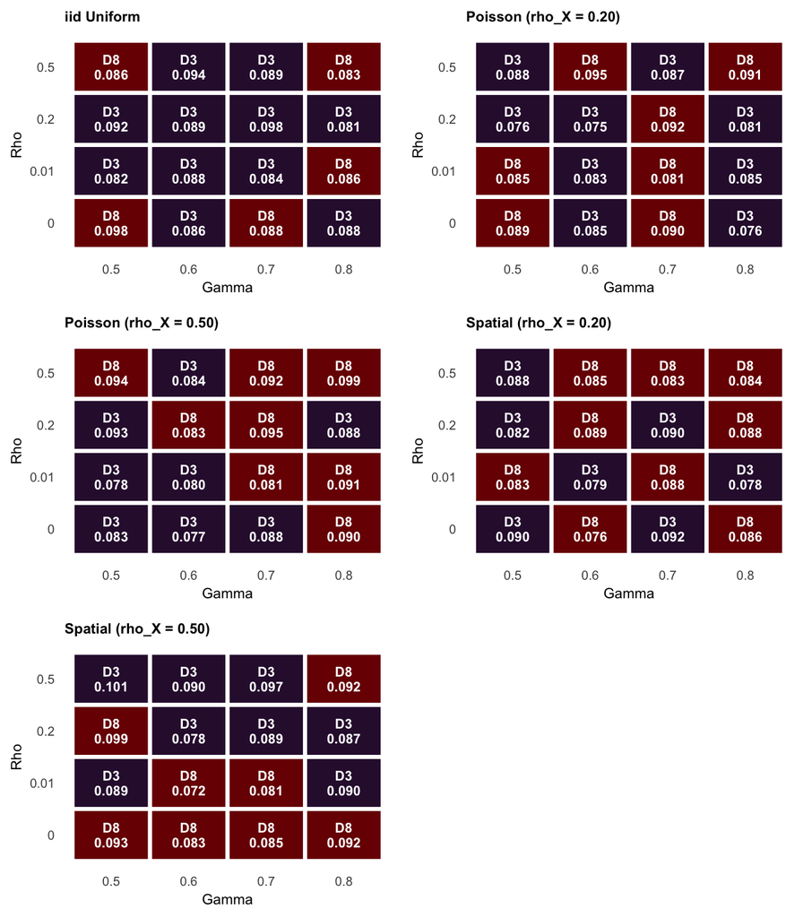

Best design heatmap: Rho vs. Gamma for each incidence config (queen contiguity). Each tile shows which design achieves the lowest average MSE at that (Rho, Gamma) combination, averaged over Spillover Type. Tile text shows the winning design abbreviation and its average MSE.

**How to read the maps:** Each tile corresponds to one (Rho, Gamma) combination. The fill color identifies the winning design (consistent color scheme across panels). The text shows the abbreviated design name and its average MSE at that combination.

**Findings:**

- **The two saturation-quadrant designs win 80 of 80 Rho x Gamma tiles** across all configs; Saturation Quadrants wins 43 (54%), so which of the two wins a given tile is close to a coin flip.
- **MSE is largely insensitive to Gamma** (the tiles within a Rho row show similar MSE values). This re-confirms the Gamma insensitivity finding from Q2.
- **MSE is not monotone in Rho** for Saturation Quadrants (average MSE 0.0885, 0.0877, 0.0888, 0.0952 at Rho = 0, 0.01, 0.2, 0.5, averaged over configs). The two saturation-quadrant designs hold ranks 1 and 2 at every Rho level.

## 6.2 Rho x Spillover Type Best-Design Maps

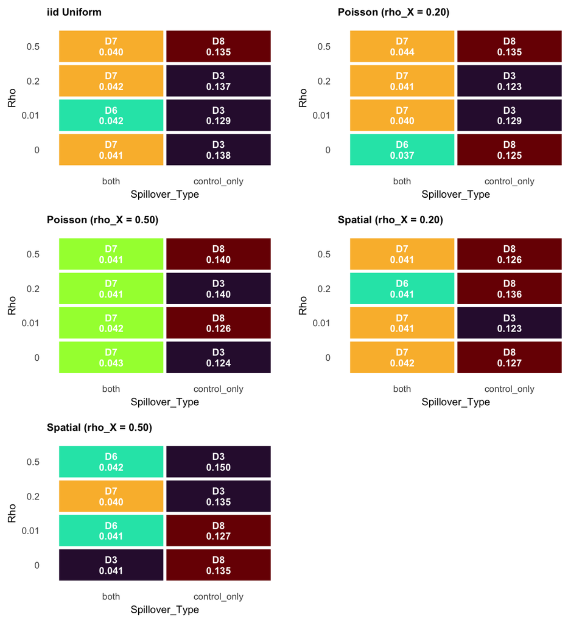

Best design heatmap: Rho vs. Spillover Type for each incidence config (queen contiguity). This reveals the key interaction: under both-direction spillover the winner is usually a balanced design, under control-only spillover a saturation-quadrant design.

**Key finding:** The Rho x Spillover_Type heatmap reveals the most practically important interaction:

- When spillover is **“control_only”**: Saturation Quadrants wins 10 of 20 tiles (50%) across all Rho levels and all configs.
- When spillover is **“both”**: Balanced Halves wins 14 of 20 tiles (70%).

This interaction is the primary driver of the overall MSE competition between Saturation Quadrants and Balanced Halves. Averaged over both spillover types, the saturation-quadrant designs have lower MSE than the balanced designs, because the MSE gaps under “control_only” are much larger than those under “both” (see the Spillover_Type discussion in Q2).

# 7 Per-Config Narrative Findings

This section synthesizes the analytical results for each incidence configuration into a cohesive narrative, presenting the six structured findings produced by `generate_commentary()` (queen contiguity, $\tau = 1.0$).

## 7.1 iid Uniform

**Finding 1 – Overall Winner:** Saturation Quadrants achieves the lowest average MSE (0.0913) across all 32 parameter combinations in this incidence configuration. The runner-up is Incidence-Guided Saturation Quadrants (avg MSE = 0.0925), which is 1.3% higher.

**Finding 2 – Dominance:** Saturation Quadrants achieves lower MSE than the runner-up (Incidence-Guided Saturation Quadrants) in 62.5% of individual scenarios, and beats the worst performer (Checkerboard) in 100.0% of scenarios. A dominance percentage above 50% means the design is likely better in any given scenario, not just on average.

**Finding 3 – Robustness:** Saturation Quadrants shows rank reversals across both Rho and Gamma levels.

**Finding 4 – Coverage:** Saturation Quadrants achieves average 95% CI coverage of 0.934 (nominal = 0.95); the highest-MSE design (Checkerboard) achieves 0.939. Under queen, coverage is near-nominal for every design and does not separate them.

**Finding 5 – Sensitivity:** For Saturation Quadrants, the most influential simulation parameter is Spillover_Type (eta-squared = 0.967), accounting for 96.7% of the design’s MSE variation across scenarios. Parameters with negligible influence (eta-squared $< 0.05$): Rho, Gamma.

**Finding 6 – Summary (descriptive):** Under iid Uniform incidence, Saturation Quadrants has the lowest average MSE, 12.0x lower than the highest-MSE design, with near-nominal coverage (0.934).

## 7.2 Poisson (rho_X = 0.20)

**Finding 1 – Overall Winner:** Saturation Quadrants achieves the lowest average MSE (0.0866) across all 32 parameter combinations in this incidence configuration. The runner-up is Incidence-Guided Saturation Quadrants (avg MSE = 0.0900), which is 4.0% higher.

**Finding 2 – Dominance:** Saturation Quadrants achieves lower MSE than the runner-up (Incidence-Guided Saturation Quadrants) in 53.1% of individual scenarios, and beats the worst performer (Checkerboard) in 100.0% of scenarios. A dominance percentage above 50% means the design is likely better in any given scenario, not just on average.

**Finding 3 – Robustness:** Saturation Quadrants shows rank reversals across both Rho and Gamma levels.

**Finding 4 – Coverage:** Saturation Quadrants achieves average 95% CI coverage of 0.939 (nominal = 0.95); the highest-MSE design (Checkerboard) achieves 0.942. Under queen, coverage is near-nominal for every design and does not separate them.

**Finding 5 – Sensitivity:** For Saturation Quadrants, the most influential simulation parameter is Spillover_Type (eta-squared = 0.953), accounting for 95.3% of the design’s MSE variation across scenarios. Parameters with negligible influence (eta-squared $< 0.05$): Rho, Gamma.

**Finding 6 – Summary (descriptive):** Under Poisson (rho_X = 0.20) incidence, Saturation Quadrants has the lowest average MSE, 12.8x lower than the highest-MSE design, with near-nominal coverage (0.939).

## 7.3 Poisson (rho_X = 0.50)

**Finding 1 – Overall Winner:** Saturation Quadrants achieves the lowest average MSE (0.0899) across all 32 parameter combinations in this incidence configuration. The runner-up is Incidence-Guided Saturation Quadrants (avg MSE = 0.0921), which is 2.5% higher.

**Finding 2 – Dominance:** Saturation Quadrants achieves lower MSE than the runner-up (Incidence-Guided Saturation Quadrants) in 53.1% of individual scenarios, and beats the worst performer (Checkerboard) in 100.0% of scenarios. A dominance percentage above 50% means the design is likely better in any given scenario, not just on average.

**Finding 3 – Robustness:** Saturation Quadrants shows rank reversals across both Rho and Gamma levels.

**Finding 4 – Coverage:** Saturation Quadrants achieves average 95% CI coverage of 0.937 (nominal = 0.95); the highest-MSE design (Checkerboard) achieves 0.939. Under queen, coverage is near-nominal for every design and does not separate them.

**Finding 5 – Sensitivity:** For Saturation Quadrants, the most influential simulation parameter is Spillover_Type (eta-squared = 0.950), accounting for 95.0% of the design’s MSE variation across scenarios. Parameters with negligible influence (eta-squared $< 0.05$): Rho, Gamma.

**Finding 6 – Summary (descriptive):** Under Poisson (rho_X = 0.50) incidence, Saturation Quadrants has the lowest average MSE, 12.0x lower than the highest-MSE design, with near-nominal coverage (0.937).

## 7.4 Spatial (rho_X = 0.20)

**Finding 1 – Overall Winner:** Incidence-Guided Saturation Quadrants achieves the lowest average MSE (0.0871) across all 32 parameter combinations in this incidence configuration. The runner-up is Saturation Quadrants (avg MSE = 0.0898), which is 3.1% higher.

**Finding 2 – Dominance:** Incidence-Guided Saturation Quadrants achieves lower MSE than the runner-up (Saturation Quadrants) in 53.1% of individual scenarios, and beats the worst performer (Checkerboard) in 96.9% of scenarios. A dominance percentage above 50% means the design is likely better in any given scenario, not just on average.

**Finding 3 – Robustness:** Incidence-Guided Saturation Quadrants shows rank reversals across both Rho and Gamma levels.

**Finding 4 – Coverage:** Incidence-Guided Saturation Quadrants achieves average 95% CI coverage of 0.942 (nominal = 0.95); the highest-MSE design (Checkerboard) achieves 0.942. Under queen, coverage is near-nominal for every design and does not separate them.

**Finding 5 – Sensitivity:** For Incidence-Guided Saturation Quadrants, the most influential simulation parameter is Spillover_Type (eta-squared = 0.967), accounting for 96.7% of the design’s MSE variation across scenarios. Parameters with negligible influence (eta-squared $< 0.05$): Rho, Gamma.

**Finding 6 – Summary (descriptive):** Under Spatial (rho_X = 0.20) incidence, Incidence-Guided Saturation Quadrants has the lowest average MSE, 12.3x lower than the highest-MSE design, with near-nominal coverage (0.942).

## 7.5 Spatial (rho_X = 0.50)

**Finding 1 – Overall Winner:** Incidence-Guided Saturation Quadrants achieves the lowest average MSE (0.0916) across all 32 parameter combinations in this incidence configuration. The runner-up is Saturation Quadrants (avg MSE = 0.0927), which is 1.1% higher.

**Finding 2 – Dominance:** Incidence-Guided Saturation Quadrants achieves lower MSE than the runner-up (Saturation Quadrants) in 40.6% of individual scenarios, and beats the worst performer (Checkerboard) in 100.0% of scenarios. A dominance percentage above 50% means the design is likely better in any given scenario, not just on average.

**Finding 3 – Robustness:** Incidence-Guided Saturation Quadrants shows rank reversals across both Rho and Gamma levels.

**Finding 4 – Coverage:** Incidence-Guided Saturation Quadrants achieves average 95% CI coverage of 0.934 (nominal = 0.95); the highest-MSE design (Checkerboard) achieves 0.943. Under queen, coverage is near-nominal for every design and does not separate them.

**Finding 5 – Sensitivity:** For Incidence-Guided Saturation Quadrants, the most influential simulation parameter is Spillover_Type (eta-squared = 0.944), accounting for 94.4% of the design’s MSE variation across scenarios. Parameters with negligible influence (eta-squared $< 0.05$): Rho, Gamma.

**Finding 6 – Summary (descriptive):** Under Spatial (rho_X = 0.50) incidence, Incidence-Guided Saturation Quadrants has the lowest average MSE, 11.8x lower than the highest-MSE design, with near-nominal coverage (0.934).

# 8 Scenario-Specific Design Lookup

For practitioners who can specify all four scenario parameters (Rho, Gamma, Spillover_Type, Neighbor_Type), the following tables provide exact design rankings for a selection of illustrative scenarios. Each table fixes a single neighbor type. The queen scenario is the primary case; the rook scenario is a sensitivity case, and under rook Checkerboard’s $\tau$ is not identified ($WZ = 1 - Z$), so its row is shown but flagged.

## 8.1 iid Uniform

iid Uniform | Scenario: Rho = 0.01, Both Spillover, Queen. Winner MSE 6.5% lower than runner-up.

| Rank | Design | MSE | Coverage | Bias | SD |
| --- | --- | --- | --- | --- | --- |
| 1 | D6: Balanced Quartiles | 0.0398 | 0.956 | +0.0125 | 0.1996 |
| 2 | D7: Balanced Halves | 0.0424 | 0.928 | -0.0044 | 0.2062 |
| 3 | D8: Inc.-Guided Sat. Q. | 0.0452 | 0.948 | +0.0320 | 0.2105 |
| 4 | D3: Sat. Quadrants | 0.0470 | 0.928 | -0.0001 | 0.2173 |
| 5 | D5: 2x2 Blocking | 0.0607 | 0.936 | -0.0012 | 0.2469 |
| 6 | D1: Checkerboard | 0.0686 | 0.952 | +0.0001 | 0.2625 |
| 7 | D4: Isolation Buffer | 0.1545 | 0.928 | -0.0238 | 0.3932 |
| 8 | D2: High Inc. Focus | 0.1768 | 0.932 | +0.0231 | 0.4207 |

iid Uniform | Scenario: High Rho (0.50), Control-Only Spillover, Rook (sensitivity; Checkerboard not identified). Winner MSE 4.9% lower than runner-up.

| Rank | Design | MSE | Coverage | Bias | SD |
| --- | --- | --- | --- | --- | --- |
| 1 | D8: Inc.-Guided Sat. Q. | 0.0912 | 0.952 | +0.0156 | 0.3023 |
| 2 | D3: Sat. Quadrants | 0.0957 | 0.940 | +0.0172 | 0.3095 |
| 3 | D7: Balanced Halves | 0.1114 | 0.952 | +0.0125 | 0.3341 |
| 4 | D6: Balanced Quartiles | 0.1221 | 0.940 | +0.0643 | 0.3442 |
| 5 | D4: Isolation Buffer | 0.1319 | 0.956 | +0.0469 | 0.3609 |
| 6 | D2: High Inc. Focus | 0.1994 | 0.964 | +0.0971 | 0.4367 |
| 7 | D5: 2x2 Blocking | 0.2316 | 0.924 | -0.0405 | 0.4805 |
| 8 | D1: Checkerboard | 0.6661 | 0.028 | -0.7923 | 0.1963 |

## 8.2 Poisson (rho_X = 0.20)

Poisson (rho X = 0.20) | Scenario: Rho = 0.01, Both Spillover, Queen. Winner MSE 11.7% lower than runner-up.

| Rank | Design | MSE | Coverage | Bias | SD |
| --- | --- | --- | --- | --- | --- |
| 1 | D7: Balanced Halves | 0.0375 | 0.944 | +0.0059 | 0.1939 |
| 2 | D6: Balanced Quartiles | 0.0419 | 0.948 | +0.0199 | 0.2041 |
| 3 | D8: Inc.-Guided Sat. Q. | 0.0428 | 0.952 | +0.0141 | 0.2067 |
| 4 | D3: Sat. Quadrants | 0.0451 | 0.940 | -0.0031 | 0.2128 |
| 5 | D5: 2x2 Blocking | 0.0537 | 0.964 | -0.0068 | 0.2320 |
| 6 | D1: Checkerboard | 0.0682 | 0.924 | +0.0071 | 0.2616 |
| 7 | D4: Isolation Buffer | 0.1508 | 0.948 | -0.0116 | 0.3889 |
| 8 | D2: High Inc. Focus | 0.1551 | 0.948 | +0.0139 | 0.3944 |

Poisson (rho X = 0.20) | Scenario: High Rho (0.50), Control-Only Spillover, Rook (sensitivity; Checkerboard not identified). Winner MSE 15.2% lower than runner-up.

| Rank | Design | MSE | Coverage | Bias | SD |
| --- | --- | --- | --- | --- | --- |
| 1 | D3: Sat. Quadrants | 0.0901 | 0.952 | +0.0288 | 0.2993 |
| 2 | D8: Inc.-Guided Sat. Q. | 0.1038 | 0.936 | +0.0859 | 0.3112 |
| 3 | D7: Balanced Halves | 0.1232 | 0.948 | +0.0140 | 0.3514 |
| 4 | D6: Balanced Quartiles | 0.1273 | 0.936 | +0.0119 | 0.3574 |
| 5 | D4: Isolation Buffer | 0.1393 | 0.924 | +0.0024 | 0.3740 |
| 6 | D5: 2x2 Blocking | 0.2212 | 0.936 | -0.0035 | 0.4712 |
| 7 | D2: High Inc. Focus | 0.2541 | 0.948 | -0.0042 | 0.5050 |
| 8 | D1: Checkerboard | 0.6932 | 0.012 | -0.8094 | 0.1953 |

## 8.3 Poisson (rho_X = 0.50)

Poisson (rho X = 0.50) | Scenario: Rho = 0.01, Both Spillover, Queen. Winner MSE 23.0% lower than runner-up.

| Rank | Design | MSE | Coverage | Bias | SD |
| --- | --- | --- | --- | --- | --- |
| 1 | D7: Balanced Halves | 0.0356 | 0.956 | +0.0023 | 0.1891 |
| 2 | D3: Sat. Quadrants | 0.0438 | 0.956 | -0.0012 | 0.2098 |
| 3 | D6: Balanced Quartiles | 0.0447 | 0.924 | -0.0065 | 0.2117 |
| 4 | D5: 2x2 Blocking | 0.0559 | 0.968 | -0.0158 | 0.2364 |
| 5 | D8: Inc.-Guided Sat. Q. | 0.0560 | 0.916 | +0.0134 | 0.2368 |
| 6 | D1: Checkerboard | 0.0616 | 0.932 | -0.0111 | 0.2484 |
| 7 | D4: Isolation Buffer | 0.1511 | 0.948 | -0.0159 | 0.3891 |
| 8 | D2: High Inc. Focus | 0.1623 | 0.944 | +0.0195 | 0.4032 |

Poisson (rho X = 0.50) | Scenario: High Rho (0.50), Control-Only Spillover, Rook (sensitivity; Checkerboard not identified). Winner MSE 22.4% lower than runner-up.

| Rank | Design | MSE | Coverage | Bias | SD |
| --- | --- | --- | --- | --- | --- |
| 1 | D3: Sat. Quadrants | 0.0845 | 0.964 | +0.0329 | 0.2894 |
| 2 | D8: Inc.-Guided Sat. Q. | 0.1034 | 0.932 | +0.0547 | 0.3174 |
| 3 | D6: Balanced Quartiles | 0.1135 | 0.944 | +0.0416 | 0.3350 |
| 4 | D4: Isolation Buffer | 0.1161 | 0.952 | +0.0026 | 0.3414 |
| 5 | D7: Balanced Halves | 0.1377 | 0.940 | +0.0035 | 0.3718 |
| 6 | D5: 2x2 Blocking | 0.1944 | 0.952 | +0.0074 | 0.4417 |
| 7 | D2: High Inc. Focus | 0.2372 | 0.944 | -0.0023 | 0.4881 |
| 8 | D1: Checkerboard | 0.6763 | 0.016 | -0.7985 | 0.1972 |

## 8.4 Spatial (rho_X = 0.20)

Spatial (rho X = 0.20) | Scenario: Rho = 0.01, Both Spillover, Queen. Winner MSE 0.4% lower than runner-up.

| Rank | Design | MSE | Coverage | Bias | SD |
| --- | --- | --- | --- | --- | --- |
| 1 | D7: Balanced Halves | 0.0453 | 0.944 | -0.0023 | 0.2132 |
| 2 | D8: Inc.-Guided Sat. Q. | 0.0455 | 0.940 | +0.0165 | 0.2132 |
| 3 | D3: Sat. Quadrants | 0.0464 | 0.944 | -0.0107 | 0.2156 |
| 4 | D6: Balanced Quartiles | 0.0491 | 0.924 | -0.0001 | 0.2220 |
| 5 | D1: Checkerboard | 0.0558 | 0.964 | -0.0081 | 0.2366 |
| 6 | D5: 2x2 Blocking | 0.0726 | 0.904 | +0.0308 | 0.2682 |
| 7 | D4: Isolation Buffer | 0.1650 | 0.928 | -0.0242 | 0.4062 |
| 8 | D2: High Inc. Focus | 0.1719 | 0.948 | +0.0292 | 0.4144 |

Spatial (rho X = 0.20) | Scenario: High Rho (0.50), Control-Only Spillover, Rook (sensitivity; Checkerboard not identified). Winner MSE 0.9% lower than runner-up.

| Rank | Design | MSE | Coverage | Bias | SD |
| --- | --- | --- | --- | --- | --- |
| 1 | D3: Sat. Quadrants | 0.0956 | 0.948 | +0.0320 | 0.3082 |
| 2 | D8: Inc.-Guided Sat. Q. | 0.0965 | 0.940 | +0.0508 | 0.3071 |
| 3 | D6: Balanced Quartiles | 0.1330 | 0.936 | +0.0353 | 0.3638 |
| 4 | D7: Balanced Halves | 0.1443 | 0.952 | +0.0429 | 0.3782 |
| 5 | D4: Isolation Buffer | 0.1605 | 0.912 | +0.0383 | 0.3996 |
| 6 | D5: 2x2 Blocking | 0.1812 | 0.944 | -0.0460 | 0.4240 |
| 7 | D2: High Inc. Focus | 0.2464 | 0.960 | -0.0319 | 0.4963 |
| 8 | D1: Checkerboard | 0.7170 | 0.016 | -0.8251 | 0.1907 |

## 8.5 Spatial (rho_X = 0.50)

Spatial (rho X = 0.50) | Scenario: Rho = 0.01, Both Spillover, Queen. Winner MSE 7.0% lower than runner-up.

| Rank | Design | MSE | Coverage | Bias | SD |
| --- | --- | --- | --- | --- | --- |
| 1 | D3: Sat. Quadrants | 0.0398 | 0.948 | -0.0060 | 0.1997 |
| 2 | D8: Inc.-Guided Sat. Q. | 0.0426 | 0.940 | +0.0106 | 0.2066 |
| 3 | D6: Balanced Quartiles | 0.0441 | 0.928 | -0.0017 | 0.2105 |
| 4 | D7: Balanced Halves | 0.0446 | 0.932 | +0.0082 | 0.2115 |
| 5 | D5: 2x2 Blocking | 0.0608 | 0.948 | +0.0072 | 0.2469 |
| 6 | D1: Checkerboard | 0.0651 | 0.920 | +0.0067 | 0.2556 |
| 7 | D2: High Inc. Focus | 0.1502 | 0.936 | +0.0440 | 0.3858 |
| 8 | D4: Isolation Buffer | 0.1642 | 0.936 | -0.0413 | 0.4040 |

Spatial (rho X = 0.50) | Scenario: High Rho (0.50), Control-Only Spillover, Rook (sensitivity; Checkerboard not identified). Winner MSE 0.7% lower than runner-up.

| Rank | Design | MSE | Coverage | Bias | SD |
| --- | --- | --- | --- | --- | --- |
| 1 | D3: Sat. Quadrants | 0.1083 | 0.936 | +0.0259 | 0.3287 |
| 2 | D6: Balanced Quartiles | 0.1091 | 0.944 | +0.0370 | 0.3289 |
| 3 | D8: Inc.-Guided Sat. Q. | 0.1168 | 0.924 | +0.0551 | 0.3380 |
| 4 | D7: Balanced Halves | 0.1341 | 0.932 | +0.0299 | 0.3657 |
| 5 | D4: Isolation Buffer | 0.1476 | 0.944 | +0.0863 | 0.3751 |
| 6 | D5: 2x2 Blocking | 0.1894 | 0.952 | -0.0118 | 0.4359 |
| 7 | D2: High Inc. Focus | 0.2669 | 0.940 | +0.0227 | 0.5171 |
| 8 | D1: Checkerboard | 0.6745 | 0.016 | -0.7960 | 0.2024 |

**How to use the lookup tables:** Identify the row that matches your anticipated trial parameters. The design at Rank 1 has the lowest MSE in that scenario. The ``Bias’’ column shows whether estimates are systematically above or below $\tau = 1.0$; a Bias close to 0 with high Coverage indicates that both point estimates and confidence intervals are reliable.

# 9 Practical Design Selection Guide

## 9.1 Decision Framework

The table below summarizes, for several situations, which design has the lowest average MSE in the queen-contiguity results. It is descriptive: it reports where each design does best and where that does not hold, and it is not the study’s final design recommendation (that choice has not yet been made). Rows other than the per-config default average over the incidence configurations named in the row.

Descriptive summary of design performance by situation (queen contiguity, tau = 1.0 unless stated). Not a final design recommendation.

| Situation | Lowest-MSE design (or design described) | Basis |
| --- | --- | --- |
| Averaged over all parameters (per config) | D3: Sat. Quadrants | Lowest MSE in 3 of 5 configs; D8: Inc.-Guided Sat. Q. in the others (statistically indistinguishable) |
| Spillover is 'both' AND Rho <= 0.01 (all configs) | D6: Balanced Quartiles | Avg MSE 0.0418; differs from the overall lowest-MSE design |
| Incidence is iid AND Rho = 0.00 | D3: Sat. Quadrants | Avg MSE 0.0910 |
| Spatial incidence (rho_X = 0.20, 0.50) AND Rho = 0.50 | D8: Inc.-Guided Sat. Q. | Avg MSE 0.0935 |
| Highest average MSE | D1: Checkerboard | MSE 11.8--12.8x the winner's in every config; coverage near nominal under queen (0.939--0.943); tau not identified under rook (coverage 0.15) |
| 2x2 Blocking, queen vs. rook | D5: 2x2 Blocking | Queen MSE 0.3192 is 2.5x its rook MSE 0.1281 |

## 9.2 Why Saturation Quadrants Wins: Mechanistic Explanation

Saturation Quadrants works by dividing the $10 \times 10$ grid into four $5 \times 5$ quadrants, where each quadrant receives a different treatment saturation level: the four levels (0.20, 0.40, 0.60, 0.80) are randomly permuted over the quadrants. Within each quadrant, clusters are randomly selected for treatment at the assigned saturation rate. Incidence-Guided Saturation Quadrants uses the same quadrant structure but assigns the saturations by the rank of each quadrant’s mean incidence (highest mean $\to$ 0.80). Under queen at $\tau = 1.0$ the two designs are statistically indistinguishable (average MSE 0.0900 vs. 0.0907; Nemenyi $p = 0.985$, Holm-adjusted Wilcoxon $p = 0.413$; `results/eight_design_supplementary/eight_design_summary.txt`), so the explanation below concerns the shared quadrant-saturation structure, not the use of incidence.

Plausible reasons this structure does well (interpretation, not tested directly):

1. **Quadrant-level saturation variation creates spatial contrast.** The ML estimator must disentangle the direct treatment effect $\tau$ from the spillover term and the spatial lag parameter $\rho$. Variable saturation makes a cluster’s own treatment $Z$ and its neighbors’ treatment $WZ$ vary more independently, which provides information about how outcomes change as treatment density changes spatially.
2. **Randomness within quadrants prevents systematic confounding.** Random selection within quadrants introduces variation uncorrelated with spatially structured incidence or outcome patterns.
3. **Quadrant-level structure respects spatial scale.** The $5 \times 5$ quadrant blocks are coarser than the neighborhoods (rook/queen) through which spillover operates, providing more contrast in $WZ$ than finer (2x2) structures.

## 9.3 Why Checkerboard Fails: Mechanistic Explanation

Checkerboard assigns treatment in a perfectly alternating, deterministic pattern, which leaves almost no independent variation in the neighbors’ treatment $WZ$ (computed from the row-standardized weight matrices in `01_spatial_setup.R`):

- **Queen (primary):** every interior cluster has four opposite-arm edge neighbors and four same-arm diagonal neighbors, so $WZ = 0.5$ for 64 of the 100 clusters and varies only on the boundary (SD of $WZ$ = 0.066). The spillover covariate is therefore nearly constant, and $\hat{\tau}$ is very imprecise: the average MSE of 1.09 is essentially all variance, bias is near zero, and coverage stays near-nominal (0.939–0.943). The problem is worst under control-only spillover.
- **Rook (sensitivity):** every neighbor is in the opposite arm, so $WZ = 1 - Z$ exactly. $Z$ and the spillover term are aliased, $\tau$ is not identified, and the oracle fit drops the Spill column (all such fits are flagged, `Z_WZ_rank_deficient`). The estimate absorbs the spillover (average bias -0.65, approximately $-\gamma$) and coverage falls to 0.15. These estimates are kept in the results but flagged.

# 10 Summary of Key Results

Overall MLE design rankings under queen contiguity (primary), averaged across all 1280 queen scenarios at tau = 1.0 (all incidence configs combined). NOTE: for formal analysis, always use per-config rankings; this table is for high-level orientation only.

| Rank | Design | Avg MSE | Avg Coverage | Avg Bias | N Scenarios |
| --- | --- | --- | --- | --- | --- |
| 1 | D3: Sat. Quadrants | 0.0900 | 0.936 | 0.0246 | 160 |
| 2 | D8: Inc.-Guided Sat. Q. | 0.0907 | 0.937 | 0.0321 | 160 |
| 3 | D7: Balanced Halves | 0.1299 | 0.936 | 0.0175 | 160 |
| 4 | D6: Balanced Quartiles | 0.1308 | 0.936 | 0.0173 | 160 |
| 5 | D4: Isolation Buffer | 0.1602 | 0.939 | 0.0026 | 160 |
| 6 | D2: High Inc. Focus | 0.2455 | 0.938 | 0.0313 | 160 |
| 7 | D5: 2x2 Blocking | 0.3192 | 0.939 | 0.0096 | 160 |
| 8 | D1: Checkerboard | 1.0869 | 0.941 | 0.0011 | 160 |

**Rook contiguity (sensitivity analysis).** The same ranking under rook contiguity is shown separately below; it is never pooled with queen. Under rook, Checkerboard’s $\tau$ is not identified ($WZ = 1 - Z$), so its row is kept but flagged.

Rook contiguity (sensitivity analysis): MLE design rankings averaged across all 1280 rook scenarios at tau = 1.0 (all incidence configs combined). Not pooled with queen.

| Rank | Design | Avg MSE | Avg Coverage | Avg Bias | N Scenarios |
| --- | --- | --- | --- | --- | --- |
| 1 | D3: Sat. Quadrants | 0.0708 | 0.940 | 0.0112 | 160 |
| 2 | D8: Inc.-Guided Sat. Q. | 0.0717 | 0.942 | 0.0185 | 160 |
| 3 | D6: Balanced Quartiles | 0.0837 | 0.940 | 0.0085 | 160 |
| 4 | D7: Balanced Halves | 0.0842 | 0.940 | 0.0084 | 160 |
| 5 | D5: 2x2 Blocking | 0.1281 | 0.938 | 0.0040 | 160 |
| 6 | D4: Isolation Buffer | 0.1329 | 0.939 | 0.0025 | 160 |
| 7 | D2: High Inc. Focus | 0.2062 | 0.939 | 0.0177 | 160 |
| 8 | D1: Checkerboard (not identified; flagged) | 0.4799 | 0.150 | -0.6519 | 160 |

**Conclusions (descriptive; queen contiguity unless stated):**

1. **Lowest average MSE:** Under queen, **Saturation Quadrants** has the lowest MSE averaged over all queen scenarios, 12.1x lower than the highest-MSE design. It is rank 1 in 3 of 5 incidence configs; Incidence-Guided Saturation Quadrants is rank 1 in the others, and the two are statistically indistinguishable (Section 9.2). Under rook (sensitivity), the two saturation-quadrant designs again hold ranks 1 and 2. This is a description of the results, not the study’s final design recommendation.
2. **Spillover type is the key moderator.** When spillover direction is “both”, **Balanced Quartiles** (and Balanced Halves) have the lowest MSE, but the leading designs differ little. When spillover is “control_only”, the two saturation-quadrant designs have clearly lower MSE than all others, splitting the Rho x Spillover_Type tiles between them (Saturation Quadrants 10 of 20).
3. **Checkerboard has the highest MSE.** Under queen its near-constant $WZ$ makes $\hat{\tau}$ very imprecise (coverage stays near-nominal); under rook $WZ = 1 - Z$, $\tau$ is not identified, and coverage falls to 0.15.
4. **Gamma has little effect on the ranking.** Design rankings are largely stable across Gamma = 0.5 to 0.8; the shifts that occur are swaps between designs with near-identical MSE (see Q2).
5. **Coverage is near-nominal for every design under queen** (0.936–0.941 averaged over scenarios), about one point below 0.95 because of the finite-sample Wald interval. Coverage therefore does not separate the designs; MSE does. The only coverage failure is Checkerboard under rook.

# 11 Sensitivity of Design Rankings to $\tau$

The tau-sweep simulation swept $\tau \in \{0.8, 1.0, 1.5, 2.0, 3.0\}$. The question here is whether the design rankings found at $\tau = 1.0$ hold across other plausible effect sizes. The figures below show the iid Uniform incidence config under queen contiguity. The $\tau$ levels share the same design draws and noise (common random numbers), so they are not independent replications.

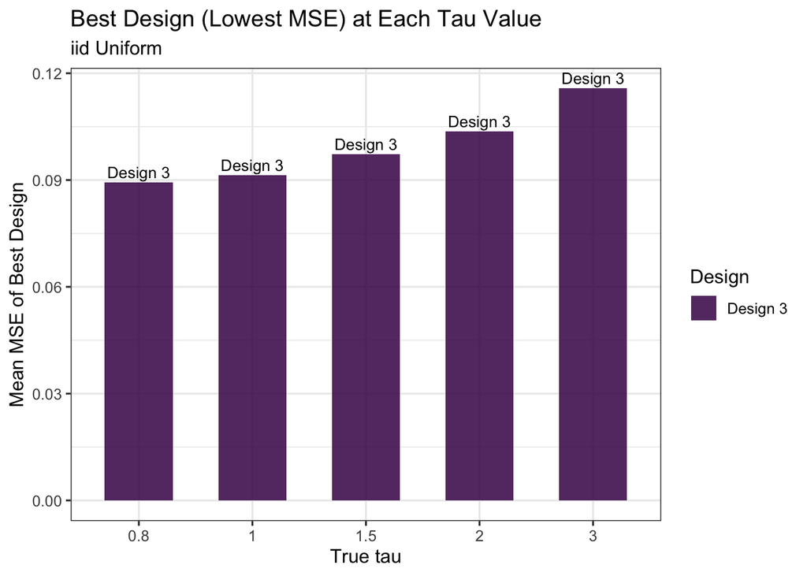

Winning design per tau level (iid Uniform, queen contiguity). A stable winner across tau means the ranking does not depend on the effect size.

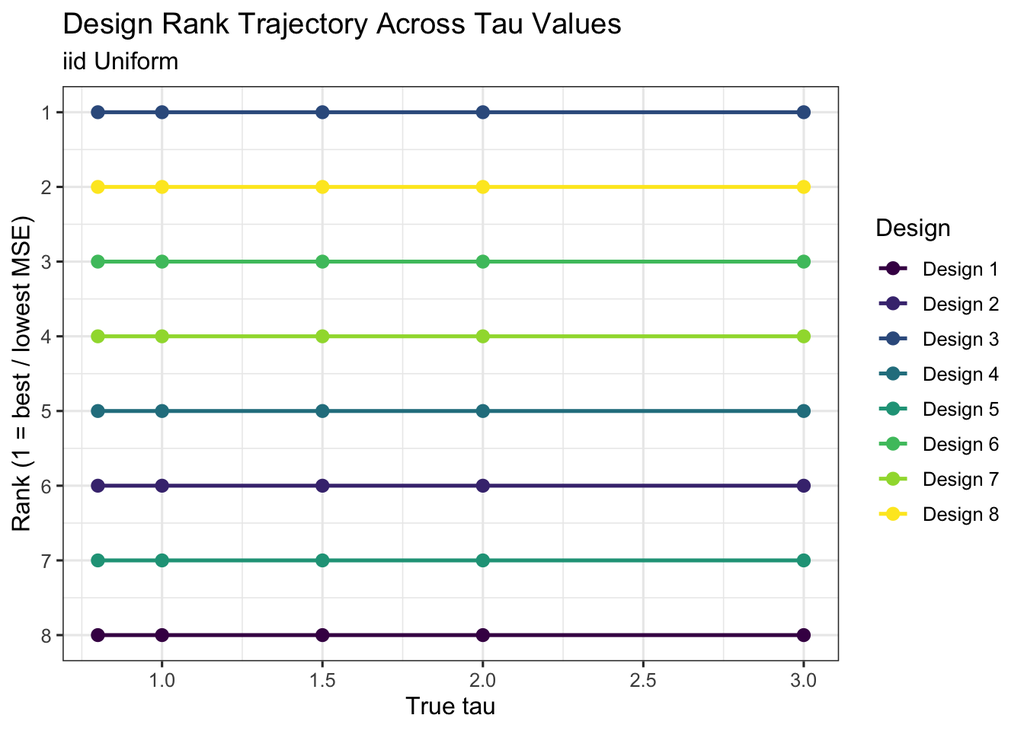

Design rank trajectories across tau values (iid Uniform, queen contiguity; rank 1 = best MSE). Flat lines mean the tau = 1.0 ranking holds at other effect sizes.

# 12 References

- Mirzaei, A. et al. (2019). Sudden unexpected death rates. *(SUD base rate 35/100,000)*
- LeSage, J. & Pace, R.K. (2009). *Introduction to Spatial Econometrics*. CRC Press.
- Bivand, R., et al. `spdep` R package.
- Bivand, R. & Piras, G. `spatialreg` R package.
- R packages used: `dplyr`, `tidyr`, `ggplot2`, `viridis`, `knitr`, `kableExtra`, `gridExtra`, `digest`

# 13 Appendix: Output Files

Output files for the design recommendation analysis.

[output not shown]